# Predicting the next word - Data Science Capstone Project

Arjhun Hariharan  
07/12/2014

### Methodology

These are the following steps that were taken to build the predictive text application.

- Loading and creating a sample of the Corpus from the given dataset (Blogs, News and Twitter)
- Preprocessing the Corpus (removing punctuation, profanity filtering etc.)
- Modelling
- Publishing the app using Shiny

### Preprocessing

The following were done as a part of prepreocessing the data:

- Removed punctuations (!?, etc)
- Dealt with the incompatible characters
- Converted to lower case
- Profanity filtering was done
- Removed whitespaces
- Numbers were not removed
- Common English stop words were not removed

### Modelling

Once the data was preprocessed, 2, 3, 4, 5 and 6 grams were tokenized from the data. With the frequency of the ngrams known along with the number of occurences of words, the ngram probability matrix was formed.

### About the app

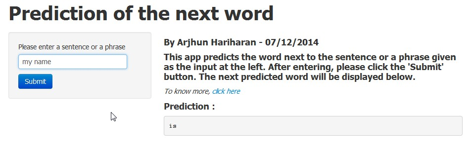

- Enter the sentence or the phrase for which you want the next word to be predicted in the text box and press 'Submit'.
- The algorithm takes the input and returns the predicted word displayed in the grey box titled 'Prediction'.
- To enter the next sentence or phrase, clear the inpur text box, type the required input and press 'Submit'.